# Social Media Addiction - Analiza EDA

Filip Zuziak

2026-01-15

## Wprowadzenie

Tworząc moją analizę EDA zdecydowałem się na wykorzystanie danych “Students Social Media Addiction” autorstwa Adil Shamim.

```r
dane <- read.csv("Students Social Media Addiction.csv")
```

Biblioteki użyte podczas analizy:

```r
library(tidyverse)
library(mice)
```

```r
library(corrplot)
library(tidyr)
```

## Zapoznanie się z danymi

Przed rozpoczęciem analizy zapoznamy się z zestawem danych, na podstawie którego przeprowadzę analizę.

```r
names(dane)
```

```
##  [1] "Student_ID"                   "Age"
##  [3] "Gender"                       "Academic_Level"
##  [5] "Country"                      "Avg_Daily_Usage_Hours"
##  [7] "Most_Used_Platform"           "Affects_Academic_Performance"
##  [9] "Sleep_Hours_Per_Night"        "Mental_Health_Score"
## [11] "Relationship_Status"          "Conflicts_Over_Social_Media"
## [13] "Addicted_Score"
```

```r
str(dane)
```

```
## 'data.frame':    705 obs. of  13 variables:
##  $ Student_ID                  : int  1 2 3 4 5 6 7 8 9 10 ...
##  $ Age                         : int  19 22 20 18 21 19 23 20 18 21 ...
##  $ Gender                      : chr  "Female" "Male" "Female" "Male" ...
##  $ Academic_Level              : chr  "Undergraduate" "Graduate" "Undergraduate" "High School" ...
##  $ Country                     : chr  "Bangladesh" "India" "USA" "UK" ...
##  $ Avg_Daily_Usage_Hours       : num  5.2 2.1 6 3 4.5 7.2 1.5 5.8 4 3.3 ...
##  $ Most_Used_Platform          : chr  "Instagram" "Twitter" "TikTok" "YouTube" ...
##  $ Affects_Academic_Performance: chr  "Yes" "No" "Yes" "No" ...
##  $ Sleep_Hours_Per_Night       : num  6.5 7.5 5 7 6 4.5 8 6 6.5 7 ...
##  $ Mental_Health_Score         : int  6 8 5 7 6 4 9 6 7 7 ...
##  $ Relationship_Status         : chr  "In Relationship" "Single" "Complicated" "Single" ...
##  $ Conflicts_Over_Social_Media : int  3 0 4 1 2 5 0 2 1 1 ...
##  $ Addicted_Score              : int  8 3 9 4 7 9 2 8 5 4 ...
```

```r
summary(dane)
```

```
##    Student_ID       Age           Gender          Academic_Level
##  Min.   :  1   Min.   :18.00   Length:705         Length:705
##  1st Qu.:177   1st Qu.:19.00   Class :character   Class :character
##  Median :353   Median :21.00   Mode  :character   Mode  :character
##  Mean   :353   Mean   :20.66
##  3rd Qu.:529   3rd Qu.:22.00
##  Max.   :705   Max.   :24.00
##    Country          Avg_Daily_Usage_Hours Most_Used_Platform
##  Length:705         Min.   :1.500         Length:705
##  Class :character   1st Qu.:4.100         Class :character
##  Mode  :character   Median :4.800         Mode  :character
##                     Mean   :4.919
##                     3rd Qu.:5.800
##                     Max.   :8.500
##  Affects_Academic_Performance Sleep_Hours_Per_Night Mental_Health_Score
##  Length:705                   Min.   :3.800         Min.   :4.000
##  Class :character             1st Qu.:6.000         1st Qu.:5.000
##  Mode  :character             Median :6.900         Median :6.000
##                               Mean   :6.869         Mean   :6.227
##                               3rd Qu.:7.700         3rd Qu.:7.000
##                               Max.   :9.600         Max.   :9.000
##  Relationship_Status Conflicts_Over_Social_Media Addicted_Score
##  Length:705          Min.   :0.00                Min.   :2.000
##  Class :character    1st Qu.:2.00                1st Qu.:5.000
##  Mode  :character    Median :3.00                Median :7.000
##                      Mean   :2.85                Mean   :6.437
##                      3rd Qu.:4.00                3rd Qu.:8.000
##                      Max.   :5.00                Max.   :9.000
```

```r
head(dane)
```

|  | Student_ID | Age | Gender | Academic_Level | Country | Avg_Daily_Usage_Hours | Most_Used_Platform | Affects_Academic_Performance | Sleep_Hours_Per_Night | Mental_Health_Score | Relationship_Status | Conflicts_Over_Social_Media | Addicted_Score |
| --- | --- | --- | --- | --- | --- | --- | --- | --- | --- | --- | --- | --- | --- |
| 1 | 1 | 19 | Female | Undergraduate | Bangladesh | 5.2 | Instagram | Yes | 6.5 | 6 | In Relationship | 3 | 8 |
| 2 | 2 | 22 | Male | Graduate | India | 2.1 | Twitter | No | 7.5 | 8 | Single | 0 | 3 |
| 3 | 3 | 20 | Female | Undergraduate | USA | 6.0 | TikTok | Yes | 5.0 | 5 | Complicated | 4 | 9 |
| 4 | 4 | 18 | Male | High School | UK | 3.0 | YouTube | No | 7.0 | 7 | Single | 1 | 4 |
| 5 | 5 | 21 | Male | Graduate | Canada | 4.5 | Facebook | Yes | 6.0 | 6 | In Relationship | 2 | 7 |
| 6 | 6 | 19 | Female | Undergraduate | Australia | 7.2 | Instagram | Yes | 4.5 | 4 | Complicated | 5 | 9 |

```r
library(mice)
md.pattern(dane,plot=FALSE)
```

```
##  /\     /\
## {  `---'  }
## {  O   O  }
## ==>  V <==  No need for mice. This data set is completely observed.
##  \  \|/  /
##   `-----'
```

```
##     Student_ID Age Gender Academic_Level Country Avg_Daily_Usage_Hours
## 705          1   1      1              1       1                     1
##              0   0      0              0       0                     0
##     Most_Used_Platform Affects_Academic_Performance Sleep_Hours_Per_Night
## 705                  1                            1                     1
##                      0                            0                     0
##     Mental_Health_Score Relationship_Status Conflicts_Over_Social_Media
## 705                   1                   1                           1
##                       0                   0                           0
##     Addicted_Score
## 705              1 0
##                  0 0
```

Przejdźmy teraz przez zmienne w naszych danych, zacznę od Gender oraz Academic_Level.

```r
table(dane$Gender,dane$Academic_Level)
```

```
##
##          Graduate High School Undergraduate
##   Female       48          15           290
##   Male        277          12            63
```

Pierwsze co widzimy to brak odpowiedniej kolejności w zmiennej Academic_Level, musimy ułożyć je w odpowiedniej kolejności.

```r
dane$Academic_Level <- factor(dane$Academic_Level,
                              levels = c("High School", "Undergraduate", "Graduate"))
table(dane$Gender,dane$Academic_Level)
```

```
##
##          High School Undergraduate Graduate
##   Female          15           290       48
##   Male            12            63      277
```

Widać, że “Undergraduate” dominowane jest przez kobiety, a Graduate przez mężczyzn. Zmieńmy jeszcze zmienną Gender na kategoryczną.

```r
dane$Gender <- as.factor(dane$Gender)
```

Teraz popatrzę na zmiennę Relationship_Status oraz Affects_Academic_Performance.

```r
table(dane$Affects_Academic_Performance)
```

```
##
##  No Yes
## 252 453
```

```r
table(dane$Relationship_Status)
```

```
##
##     Complicated In Relationship          Single
##              32             289             384
```

Również zmieńmy te zmienne na kategoryczne.

```r
dane$Affects_Academic_Performance <- as.factor(dane$Affects_Academic_Performance)
dane$Relationship_Status <- factor(dane$Relationship_Status,
                              levels = c("Single", "In Relationship", "Complicated"))
```

## Zmienne

Po analize naszych danych oraz przejrzeniu samego pliku możemy wypisać sobie zmienne

- **Student ID** (ID studenta)
- **Age** (Wiek)
- **Gender** (Płeć)
- **Academic_Level** (Wykształcenie)
- **Country** (Kraj)
- **Avg_Daily_Usage_Hours** (Średnie używanie Social Mediów)
- **Most_Used_Platform** (ID studenta)
- **Student ID** (ID studenta)
- **Affects_Academic_Performance** (Wpływ na wyniki w nauce)
- **Sleep_Hours_Per_Night** (Średnia liczba godzin snu)
- **Mental_Health_Score** (Ocena zdrowia psychicznego)
- **Relationship_Status** (Status związku)
- **Conflicts_Over_Social_Media** (Liczba konfliktów przez social media)
- **Addicted_Score** (Wynik uzależnienia)

## Wpływ związku na osiągi naukowe

Na początek sprawdźmy, czy status związku wpływa na osiągi naukowe?

```r
table(dane$Affects_Academic_Performance,dane$Relationship_Status)
```

```
##
##       Single In Relationship Complicated
##   No     111             133           8
##   Yes    273             156          24
```

Pokażmy to sobie na wykresie, użyjemy position=“fill” aby zobaczyć proporcje.

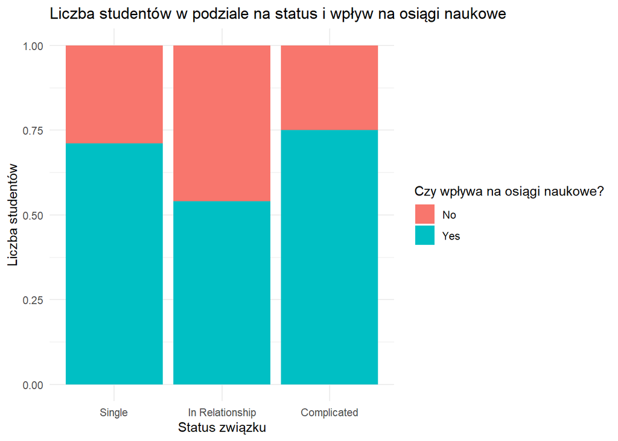

```r
dane %>%
  filter(!is.na(Relationship_Status), !is.na(Affects_Academic_Performance)) %>%
  ggplot(aes(x = Relationship_Status, fill = Affects_Academic_Performance)) +
  geom_bar(position="fill") +

  theme_minimal() +
  labs(title = "Liczba studentów w podziale na status i wpływ na osiągi naukowe",
       x = "Status związku",
       y = "Liczba studentów",
       fill = "Czy wpływa na osiągi naukowe?")
```

Zauważamy, że osoby będące singlem/singielką mają większą tendecję do pogorszenia swoich wyników w nauce, bardzo podobnie jest w statusie `Complicated` chociaż tutaj musimy wziąć pod uwagę, że grupa osób jest o wiele mniejsza, u osób w związku proporcja ta się wyrównuje. Zróbmy dla tego problemu jeszcze test niezależności Chi-kwadrat:

```r
chi <- chisq.test(table(dane$Relationship_Status, dane$Affects_Academic_Performance))
chi
```

```
##
##  Pearson's Chi-squared test
##
## data:  table(dane$Relationship_Status, dane$Affects_Academic_Performance)
## X-squared = 22.714, df = 2, p-value = 1.169e-05
```

Wartość p < 0.05 informuje nas, że dwie zmienne są od siebie zależne co potwierdza to co widzimy na wykresie.

## Czy śpiący dłużej czują się lepiej psychicznie?

Zajmijmy się teraz zmiennymi `Sleep_Hours_Per_Night` i `Mental_Health_Score`.

```r
table(dane$Mental_Health_Score)
```

```
##
##   4   5   6   7   8   9
##  29 173 219 178 105   1
```

```r
summary(dane$Sleep_Hours_Per_Night)
```

```
##    Min. 1st Qu.  Median    Mean 3rd Qu.    Max.
##   3.800   6.000   6.900   6.869   7.700   9.600
```

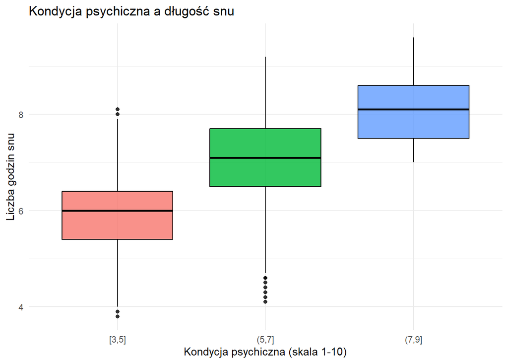

```r
dane %>%
  mutate(
    Sleep_temp= Sleep_Hours_Per_Night,
    Health_temp = cut_width(Mental_Health_Score, width = 2, boundary = 1)
  ) %>%
  ggplot(aes(x = Health_temp, y = Sleep_temp, fill = Health_temp)) +
  geom_boxplot(color = "black", outlier.color = "black", alpha = 0.8) +
  theme_minimal() +
  theme(legend.position = "none") +
  labs(title = "Kondycja psychiczna a długość snu",
       x = "Kondycja psychiczna (skala 1-10)",
       y = "Liczba godzin snu",
       fill = "Przedział punktowy")
```

Widzimy, że lepsza kondycja psychiczna idzie z dłuższą ilością snu, dane posiadają osoby, które pomimo małej ilości snu posiadają kondycje psychiczną w przedziale (5:7], zależność między zmiennymi jest widoczna poprzez wzrost wysokości kolejnych boxplotów.

## Czy długie używanie social mediów zabiera nam sen?

Sprawdźmy teraz jak średnia dzienna ilość korzystania z social mediów (`Avg_Daily_Usage_Hours`) wpływa na ilość snu, zanim jednak sprawdźmy jak wyglądają dane `Avg_Daily_Usage_Hours`:

```r
summary(dane$Avg_Daily_Usage_Hours)
```

```
##    Min. 1st Qu.  Median    Mean 3rd Qu.    Max.
##   1.500   4.100   4.800   4.919   5.800   8.500
```

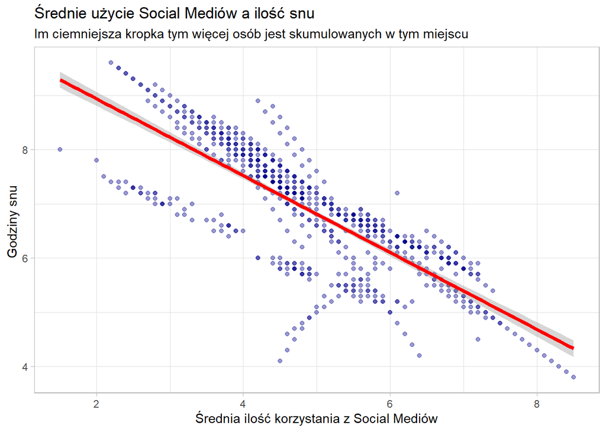

```r
dane %>%
  ggplot(aes(x = Avg_Daily_Usage_Hours, y = Sleep_Hours_Per_Night)) +
  geom_point(alpha = 0.4, color = "darkblue") +
  geom_smooth(method = "lm",formula = y ~ x, color = "red", size = 1.5) +
  theme_light() +
  labs(title = "Średnie użycie Social Mediów a ilość snu",
       subtitle = "Im ciemniejsza kropka tym więcej osób jest skumulowanych w tym miejscu",
       x = "Średnia ilość korzystania z Social Mediów",
       y = "Godziny snu ")
```

Linia trendu sugeruje, że między zmiennymi występuje korelacja ujemna - więcej korzystania z mediów społecznościowych zmiejsza ilość snu. Są jednak studenci oddaleni od linii trendu śpiący krótko pomimo nie aż tak dużego czasu spędzonego w aplikacjach.

## Im więcej korzystamy tym bardziej się uzależniamy?

Kontynuując naszą analizę, zostawiamy `Avg_Daily_Usage_Hours` pod lupą, sprawdźmy tym razem jak ta zmienna wpływa na `Addicted_Score`, wnioskując na podstawie wykresu wyżej możemy postawić hipotezę, że średni czas wpływa na poziom uzależnienia. Sprawdźmy jednak co pokaże nam na ten temat relacja między tymi zmiennymi.

```r
dane %>%
  group_by(Addicted_Score) %>%
summarise(
    srednia=mean(Avg_Daily_Usage_Hours,na.rm=TRUE),
    mediana=median(Avg_Daily_Usage_Hours,na.rm=TRUE),
    srednia=mean(Avg_Daily_Usage_Hours,na.rm=TRUE),
    odchylenie=sd(Avg_Daily_Usage_Hours,na.rm=TRUE),
    liczba_studentow = n()
  )
```

| Addicted_Score | srednia | mediana | odchylenie | liczba_studentow |
| --- | --- | --- | --- | --- |
| 2 | 1.500000 | 1.50 | NA | 1 |
| 3 | 2.975000 | 3.05 | 0.5836666 | 16 |
| 4 | 3.262651 | 3.30 | 0.6244433 | 83 |
| 5 | 4.175735 | 4.30 | 0.5442625 | 136 |
| 6 | 4.395082 | 4.50 | 0.5024693 | 61 |
| 7 | 5.103828 | 5.10 | 0.7551647 | 209 |
| 8 | 5.970833 | 6.10 | 0.7591747 | 144 |
| 9 | 7.005455 | 7.00 | 0.6407224 | 55 |

Analizując zestawione statystyki opisowe, widzimy wyraźną, monotoniczną tendencję wzrostową, gdzie wyższym wartościom wskaźnika Addicted_Score odpowiadają sukcesywnie rosnące poziomy średniej oraz mediany. Zauważamy również wysoką zbieżność obu tych miar, co sugeruje symetryczny rozkład badanej cechy w poszczególnych podgrupach. Warto zwrócić uwagę na stabilność odchylenia standardowego w liczniejszych grupach, choć interpretację dla najniższego punktu skali musimy traktować ostrożnie ze względu na jego jednostkową liczebność.

## Które platformy dominują?

Stwórzmy wykres słupkowy dla platform używanych przez użytkowników.

```r
table(dane$Most_Used_Platform)
```

```
##
##  Facebook Instagram KakaoTalk      LINE  LinkedIn  Snapchat    TikTok   Twitter
##       123       249        12        12        21        13       154        30
## VKontakte    WeChat  WhatsApp   YouTube
##        12        15        54        10
```

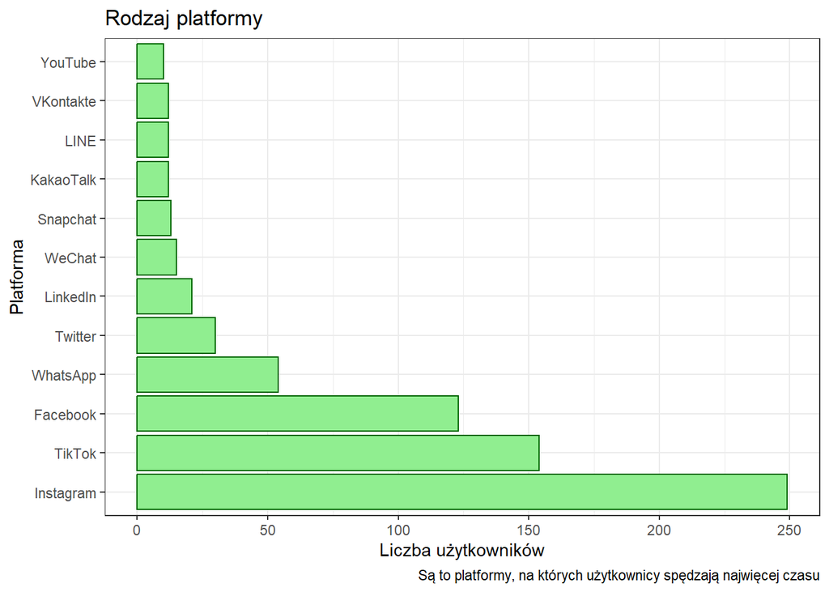

```r
dane %>%
  ggplot(aes(x = fct_infreq(Most_Used_Platform)))+
  geom_bar(color="darkgreen",fill="lightgreen")+
  theme_bw()+
  coord_flip() +
  labs(title="Rodzaj platformy",
       caption="Są to platformy, na których użytkownicy spędzają najwięcej czasu",
       x="Platforma",
       y="Liczba użytkowników")
```

Wykres słupkowy pokazuje dominację 3 platform: Instagrama, TikToka i Facebooka, reszta tworzy nam tzw “Długi ogon”. Badanie zależności na wartościach typu 12 lub 15 może być bardzo mylące gdyż już jedna wartość odstająca może zaburzyć nasze dane. Połączmy sobie te dane w kategorie “Other”.

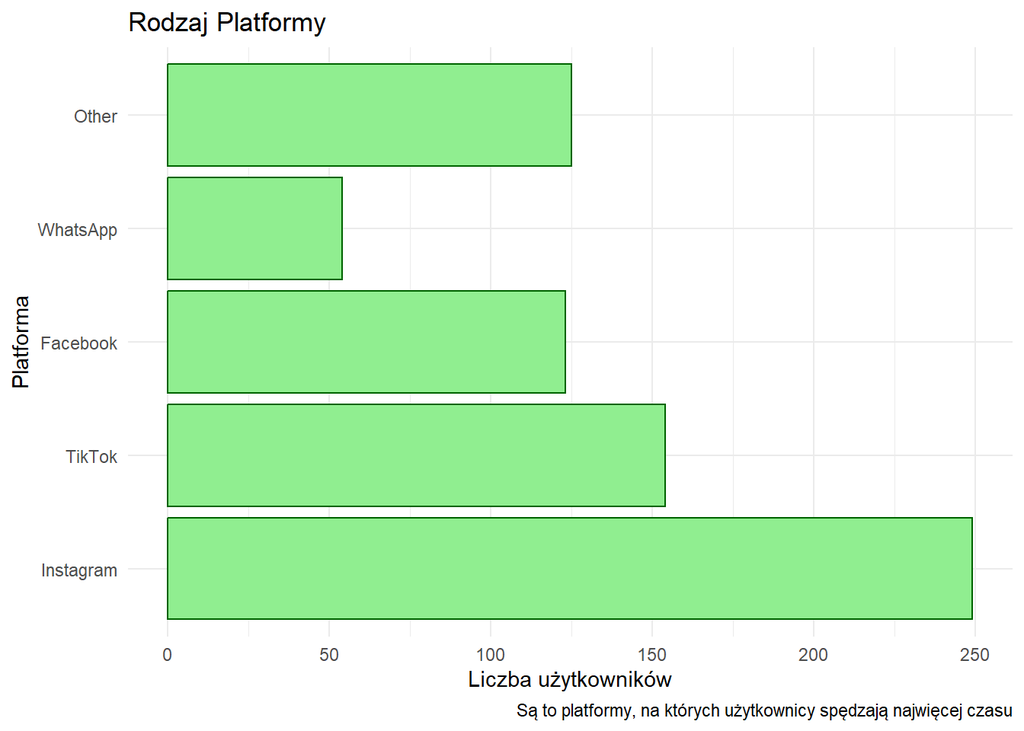

```r
dane_temp <- dane %>%
  mutate(
    Most_Used_Platform= fct_lump_n(Most_Used_Platform, n = 4, other_level = "Other"),
    Most_Used_Platform=fct_infreq(Most_Used_Platform),
    Most_Used_Platform=fct_relevel(Most_Used_Platform, "Other", after = Inf)
  )

ggplot(dane_temp, aes(x = Most_Used_Platform)) +
  geom_bar(fill = "lightgreen", color = "darkgreen") +
  coord_flip() +
  theme_minimal() +
  labs(title = "Rodzaj Platformy",y="Liczba użytkowników",x="Platforma",caption="Są to platformy, na których użytkownicy spędzają najwięcej czasu")
```

Po stworzeniu `Other` zobaczmy jak podział platform wygląda w poszczególnych krajach.

```r
table(dane$Country,fct_lump_n(dane$Most_Used_Platform, n = 5, other_level = "Other"))
```

```
##
##                   Facebook Instagram TikTok Twitter WhatsApp Other
##   Afghanistan            0         0      0       0        0     1
##   Albania                0         0      1       0        0     0
##   Andorra                0         0      1       0        0     0
##   Argentina              0         0      1       0        0     0
##   Armenia                0         1      0       0        0     0
##   Australia              6         8      0       0        0     0
##   Austria                0         1      0       0        0     0
##   Azerbaijan             0         0      1       0        0     0
##   Bahamas                0         0      0       0        0     1
##   Bahrain                0         0      0       0        0     1
##   Bangladesh             4        12      4       0        0     0
##   Belarus                0         0      0       0        0     1
##   Belgium                0         0      1       0        0     0
##   Bhutan                 0         0      0       0        0     1
##   Bolivia                0         0      0       0        0     1
##   Bosnia                 0         0      0       0        0     1
##   Brazil                 0         1      2       0        4     1
##   Bulgaria               0         0      0       0        0     1
##   Canada                 1        17     16       0        0     0
##   Chile                  0         0      0       0        0     1
##   China                  0         0      1       0        0    15
##   Colombia               0         1      0       0        0     0
##   Costa Rica             0         1      0       0        0     0
##   Croatia                0         1      0       0        0     0
##   Cyprus                 1         0      0       0        0     0
##   Czech Republic         0         0      0       0        0     1
##   Denmark               19         2      0       6        0     0
##   Ecuador                0         1      0       0        0     0
##   Egypt                  0         0      0       0        0     1
##   Estonia                0         1      0       0        0     0
##   Finland                1         6      1       0        0     0
##   France                 2        22      0       2        0     1
##   Georgia                0         0      0       0        0     1
##   Germany                7         6      0       0        0     1
##   Ghana                  0         0      0       0        0     1
##   Greece                 1         0      0       0        0     0
##   Hong Kong              0         1      0       0        0     0
##   Hungary                0         0      1       0        0     0
```

[output cut: 57 more lines]

```
##   Taiwan                 0         0      0       0        0     1
##   Tajikistan             0         0      0       0        0     1
##   Thailand               0         1      0       0        0     0
##   Trinidad               0         0      1       0        0     0
##   Turkey                 0        14     13       0        0     0
##   UAE                    0         8      0       0        0     0
##   UK                     8         6      3       4        0     1
##   Ukraine                0         0      1       0        0     0
##   Uruguay                0         0      0       0        0     1
##   USA                    0        19     16       5        0     0
##   Uzbekistan             0         0      1       0        0     0
##   Vatican City           0         0      0       0        0     1
##   Venezuela              1         0      0       0        0     0
##   Vietnam                1         0      0       0        0     0
##   Yemen                  1         0      0       0        0     0
```

Obecna tabela jest nieczytelna ze względu na obecność wielu krajów reprezentowanych przez pojedynczych użytkowników. Zaburza to obraz danych dla grup o większej liczebności. W celu poprawy jakości analizy, odfiltrujemy kraje o małej próbie badawczej.

```r
kraje_znaczace<-dane %>%
  add_count(Country) %>%
  filter(n>15) %>%
  mutate(Most_Used_Platform = fct_lump_n(Most_Used_Platform, n = 5, other_level = "Other"))
table(kraje_znaczace$Country,kraje_znaczace$Most_Used_Platform)
```

```
##
##               Facebook Instagram TikTok Twitter WhatsApp Other
##   Bangladesh         4        12      4       0        0     0
##   Canada             1        17     16       0        0     0
##   China              0         0      1       0        0    15
##   Denmark           19         2      0       6        0     0
##   France             2        22      0       2        0     1
##   India             13         9      5       1       25     0
##   Ireland            0        16      9       2        0     0
##   Italy              4         6      8       2        0     1
##   Japan              0         0      1       8        0    12
##   Maldives           0         9     10       0        0     0
##   Mexico             6         1      2       0       18     0
##   Nepal              4         0     14       0        0     1
##   Pakistan           0        18      1       0        0     0
##   Poland            11         1      4       0        0     0
##   Russia             0         8      0       0        0    13
##   Spain              4        10     13       0        0     0
##   Sri Lanka         14         0      4       0        0     1
##   Switzerland        5        20      1       0        0     1
##   Turkey             0        14     13       0        0     0
##   UK                 8         6      3       4        0     1
##   USA                0        19     16       5        0     0
```

Tabela pokazuje nam bardzo ciekawe statystyki, zajmijmy się Chinami, Japonią oraz Rosją - dominuje w nich kategoria `Other`, spowodowane to jest faktem iż ich użytkownicy nie korzystają z zachodnich aplikacji. Dominacje WhatsApp widzimy w Meksyku i Indiach, tylko te dwa mają jakiekolwiek osoby korzystające z tej aplikacji. Rynek Ameryki Północnej jest podzielony między TikToka a Instagrama, tego drugiego zaś bardzo lubi używać Europa Zachodnia.

## Agresja w Social Mediach

Zostańmy dalej przy krajach, sprawdźmy jaki kraj jest najbardziej agresywny w sieci.

```r
summary(dane$Conflicts_Over_Social_Media)
```

```
##    Min. 1st Qu.  Median    Mean 3rd Qu.    Max.
##    0.00    2.00    3.00    2.85    4.00    5.00
```

```r
agresja<-dane %>%
  add_count(Country) %>%
  filter(n>10) %>%
  group_by(Country) %>%
  summarise(
    srednia_konfliktow=mean(Conflicts_Over_Social_Media,na.rm=TRUE),
    badani=n()
  ) %>%
  arrange(desc(srednia_konfliktow))
head(agresja,5)
```

| Country | srednia_konfliktow | badani |
| --- | --- | --- |
| USA | 3.800000 | 40 |
| India | 3.528302 | 53 |
| Bangladesh | 3.450000 | 20 |
| Pakistan | 3.421053 | 19 |
| Mexico | 3.333333 | 27 |

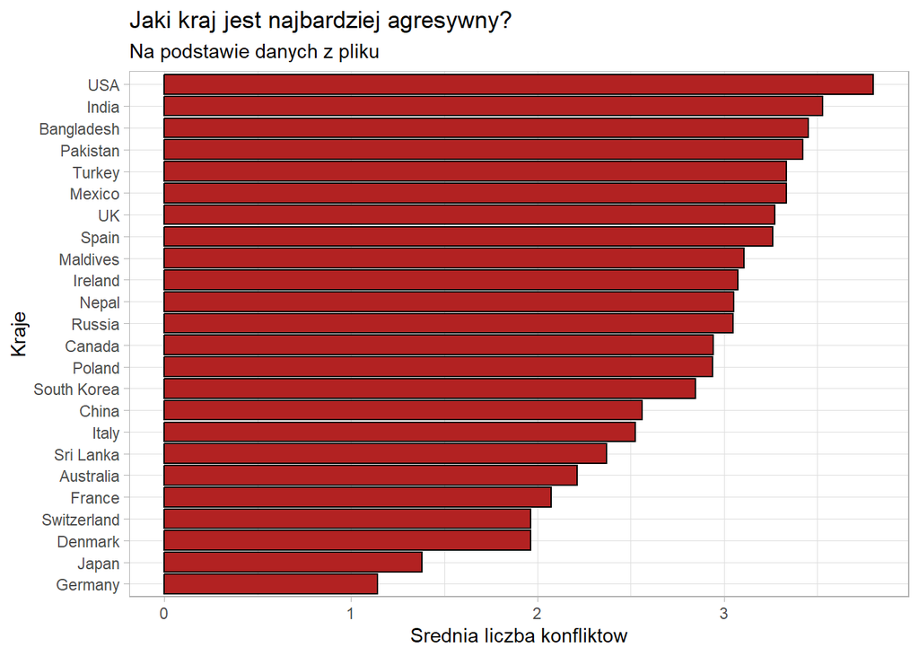

```r
ggplot(agresja, aes(x=reorder(Country,srednia_konfliktow), y = srednia_konfliktow)) +
  geom_col(fill="firebrick", color="black") +
  coord_flip()+
  theme_light()+
  labs(
    title="Jaki kraj jest najbardziej agresywny?",
    subtitle="Na podstawie danych z pliku",
    x="Kraje",
    y="Srednia liczba konfliktow"
  )
```

Na podstawie naszych danych wychodzi, że USA, Indie, Bangladesz, Pakistan i Turcja to najbardziej agresywne kraje (liczba osób z kraju >10).`Summary` pokazuje nam również, że mediana jest równa 3 co świadczy o tym, że internet nie jest miejscem zbytnio miłym. Widzimy, że użytkownicy ze WSZYSTKICH krajów na wykresie średnio biorą udział w > 1 konflikcie przez social media.

Kontynuujmy analizę, nie oddalajmy się zbytnio ale sprawdźmy czy osoby bardziej wykształcone wciągają się w więcej konfliktów, niż osoby, które są mniej wykształcone.

```r
table(dane$Academic_Level,dane$Conflicts_Over_Social_Media)
```

```
##
##                   0   1   2   3   4   5
##   High School     0   2   0   1  24   0
##   Undergraduate   0  15 111 124  94   9
##   Graduate        4  30  93 136  56   6
```

Na pierwszy rzut oka możemy zauważyć parę ciekawych informacji, między innymi, że wśród osób ze szkół średnich zdecydowana większość posiada aż 4 konflikty. Zilustrujmy tą tabelkę na wykresie:

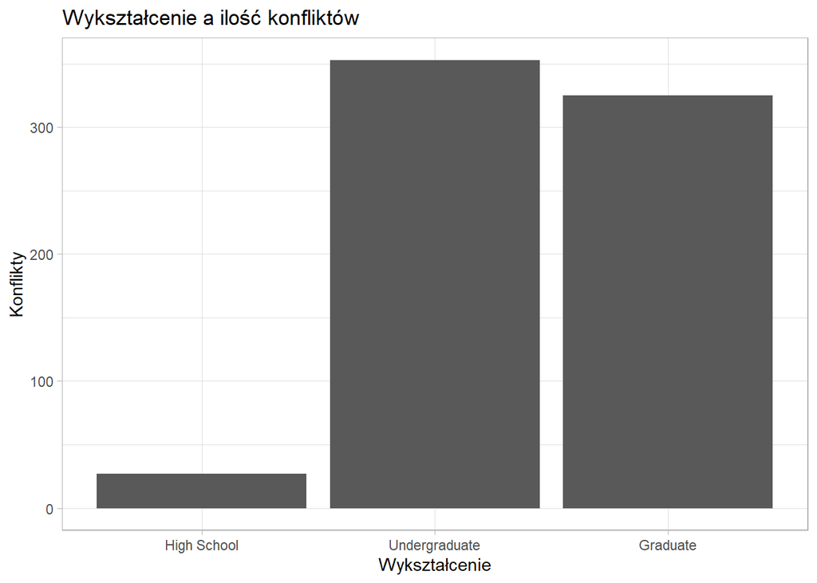

```r
ggplot(dane,aes(x=Academic_Level,fill=Conflicts_Over_Social_Media))+
  geom_bar()+
  theme_light()+
  labs(
    title="Wykształcenie a ilość konfliktów",
    x="Wykształcenie",
    y="Konflikty",
    fill="Ilość Konfliktów"
  )
```

Mamy wykres ale nie oddaje on tego co tabelka, musimy zamienić zmienną `Conflicts_Over_Social_Media` na zmienną kategoryczną, nie podmnieniajmy jej jednak, a dodajmy jako dodatkową kolumnę bo może nam się ona jeszcze przydać przy liczeniu statystyk opisowych.

```r
dane <- dane %>%
  mutate(Conflicts_Over_Social_Media_Factor = as.factor(Conflicts_Over_Social_Media))
```

Stwórzmy ponownie wykres.

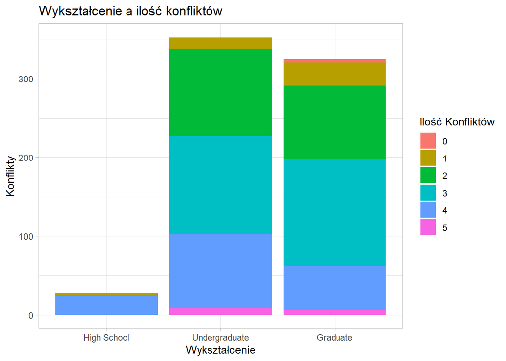

```r
ggplot(dane,aes(x=Academic_Level,fill=Conflicts_Over_Social_Media_Factor))+
  geom_bar()+
  theme_light()+
  labs(
    title="Wykształcenie a ilość konfliktów",
    x="Wykształcenie",
    y="Konflikty",
    fill="Ilość Konfliktów"
  )
```

Co możemy zauważyć? Oczywiście to co stwierdziliśmy na podstawie tabelki - w przypadku `High School` zdecydowana większość osób posiada 4 konflikty. W przypadku dwóch pozostałych ponad połowę stanowią osoby z liczbą konfliktów 3 oraz 4. Grupa osób z najwyższym wykształceniem posiada również niewielką część osób bez konfliktów.

```r
szkolaw<-dane %>%
  filter(Academic_Level == "High School") %>%
  count(Relationship_Status) %>%
  mutate(Procent = n / sum(n) * 100) %>%
  mutate(Procent = round(Procent, 1))
szkolaw
```

| Relationship_Status | n | Procent |
| --- | --- | --- |
| Single | 12 | 44.4 |
| In Relationship | 6 | 22.2 |
| Complicated | 9 | 33.3 |

Ciężko tutaj o jakiekolwiek wnioski, nie posiadamy dokładnych informacji co oznacza status `Complicated`. Niemniej, bez twardych definicji, traktujemy tę kategorię ostrożnie i nie łączymy jej jednoznacznie z grupą singli ani osób w stałych związkach.

## Kłótnie na mediach społecznościowcyh ważniejsze od nauki?

Twardo trzymamy się `Conflicts_Over_Social_Media`. Za pomocą statystyk opisowych zobaczmy czy spięcia w sieci wpływają na naukę.

```r
klotnie_opisowe <- dane %>%
  group_by(Affects_Academic_Performance) %>%
  summarise(
    klotnie_srednia = mean(Conflicts_Over_Social_Media, na.rm = TRUE),
    klotnie_mediana = median(Conflicts_Over_Social_Media, na.rm = TRUE),
    klotnies_och=sd(Conflicts_Over_Social_Media,na.rm=TRUE)
  )
klotnie_opisowe
```

| Affects_Academic_Performance | klotnie_srednia | klotnie_mediana | klotnies_och |
| --- | --- | --- | --- |
| No | 1.781746 | 2 | 0.4507454 |
| Yes | 3.443709 | 3 | 0.5718596 |

Porównując obie grupy, zauważamy, że studenci deklarujący negatywny wpływ social mediów na naukę mają przeciętnie wyższą liczbę konfliktów niż pozostali. Wyższe wartości, widoczne także w medianie, wskazują, że problemy w nauce częściej idą w parze z napięciami w relacjach.

## Co i jak wpływa na uzależnienie?

Wykorzystajmy teraz macierz korrelacji aby sprawdzić jak poszczególne kryteria wpływają na nasz `Addicted Score`.

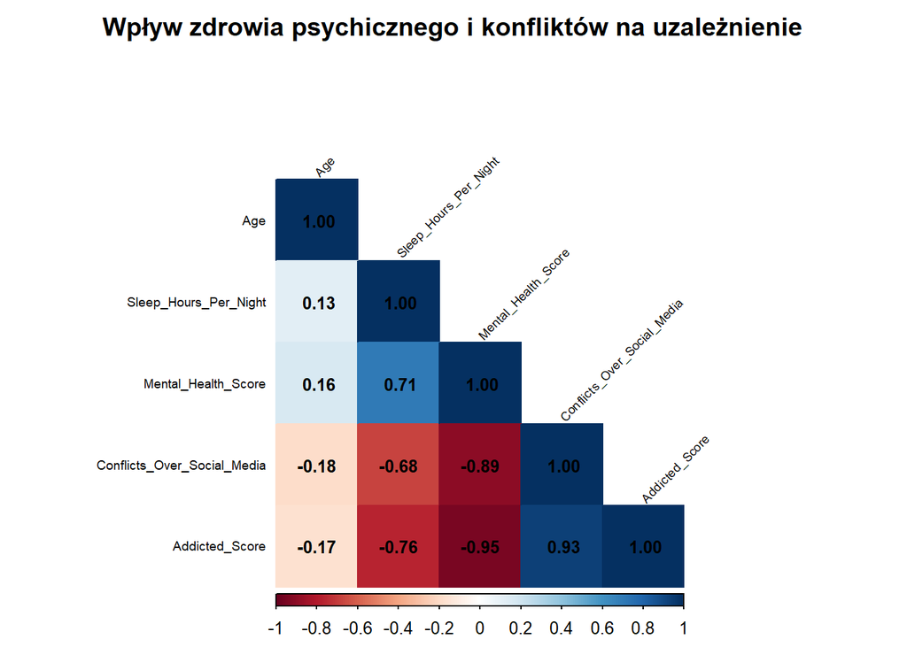

```r
dane_kor <- dane %>%
  select(Age,Sleep_Hours_Per_Night, Mental_Health_Score,
         Conflicts_Over_Social_Media, Addicted_Score) %>%
  na.omit()
korelacja <- cor(dane_kor)
corrplot(korelacja,
         method = "color",
         type = "lower",
         addCoef.col = "black",
         tl.col = "black",
         tl.cex = 0.6,
         tl.srt = 45,
         number.cex = 0.8,
         title = "Wpływ zdrowia psychicznego i konfliktów na uzależnienie",
         mar = c(0,0,2,0)
)
```

Pominąłem tutaj zmienną Avg_Daily_Usage_Hours, ponieważ jej wpływ omówiłem już wyżej.Popatrzmy na to, co najmocniej koreluje z Addicted_Score.Szczególnie rzuca się w oczy wynik -0,95 przy `Mental_Health_Score` oraz -0,76 przy `Sleep_Hours_Per_Night`. Te liczby potwierdzają to, co podpowiada intuicja: gorsza kondycja psychiczna i mniejsza ilość snu wiążą się z wyższym poziomem uzależnienia. Z kolei przy `Conflicts_Over_Social_Media` mamy bardzo silną korelację dodatnią – im więcej konfliktów w sieci, tym wyższy wynik uzależnienia.

Obliczmy statystyki opisowe:

```r
korelacja_opisowe <- dane %>%
  group_by(Addicted_Score) %>%
  summarise(
    sen_srednia = mean(Sleep_Hours_Per_Night, na.rm = TRUE),
    sen_mediana = median(Sleep_Hours_Per_Night, na.rm = TRUE),
    sen_sd = sd(Sleep_Hours_Per_Night, na.rm = TRUE),
    mental_srednia = mean(Mental_Health_Score, na.rm = TRUE),
    mental_mediana = median(Mental_Health_Score, na.rm = TRUE),
    mental_sd = sd(Mental_Health_Score, na.rm = TRUE),
    liczba_studentow = n()
  )
korelacja_opisowe
```

| Addicted_Score | sen_srednia | sen_mediana | sen_sd | mental_srednia | mental_mediana | mental_sd | liczba_studentow |
| --- | --- | --- | --- | --- | --- | --- | --- |
| 2 | 8.000000 | 8.00 | NA | 9.000000 | 9 | NA | 1 |
| 3 | 8.143750 | 8.15 | 0.4884926 | 8.000000 | 8 | 0.0000000 | 16 |
| 4 | 8.109639 | 8.10 | 0.7274436 | 7.963855 | 8 | 0.1877845 | 83 |
| 5 | 7.641912 | 7.50 | 0.5846880 | 7.066176 | 7 | 0.2495093 | 136 |
| 6 | 7.534426 | 7.60 | 0.6217945 | 6.786885 | 7 | 0.4129065 | 61 |
| 7 | 6.661722 | 6.70 | 0.8478303 | 5.870813 | 6 | 0.3362117 | 209 |
| 8 | 5.911806 | 6.00 | 0.6494211 | 5.159722 | 5 | 0.3861808 | 144 |
| 9 | 5.249091 | 5.30 | 0.5971763 | 4.490909 | 4 | 0.5045250 | 55 |

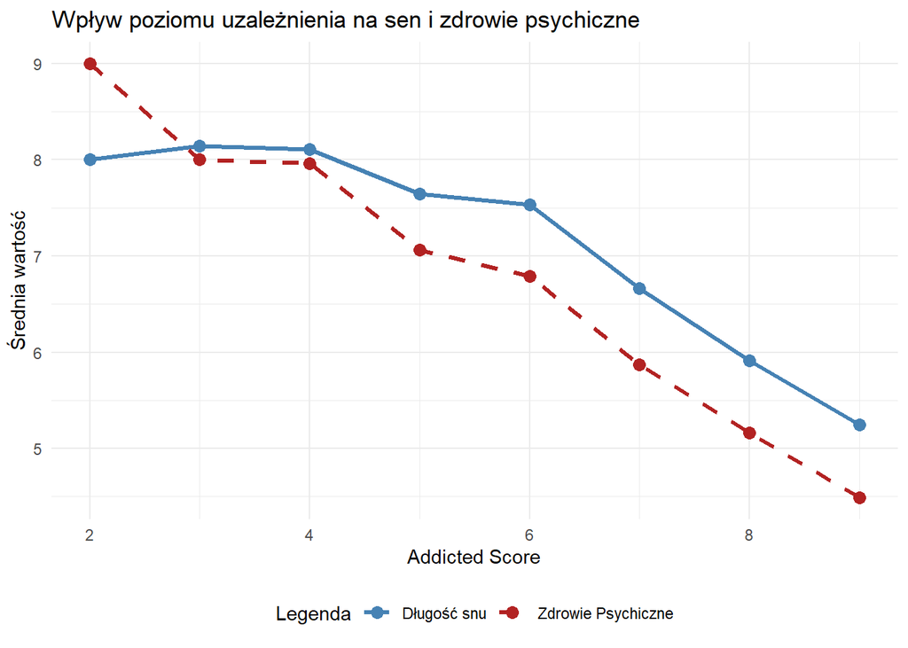

```r
ggplot(korelacja_opisowe, aes(x = Addicted_Score)) +
  geom_line(aes(y = sen_srednia, color = "Długość snu"), size = 1.2) +
  geom_point(aes(y = sen_srednia, color = "Długość snu"), size = 3) +
  geom_line(aes(y = mental_srednia, color = "Zdrowie Psychiczne"), size = 1.2, linetype = "dashed") +
  geom_point(aes(y = mental_srednia, color = "Zdrowie Psychiczne"), size = 3) +
  labs(
    title = "Wpływ poziomu uzależnienia na sen i zdrowie psychiczne",
    x = "Addicted Score",
    y = "Średnia wartość",
    color = "Legenda"
  ) +
  scale_color_manual(values = c("Długość snu" = "steelblue", "Zdrowie Psychiczne" = "firebrick")) +
  theme_minimal() +
  theme(legend.position = "bottom")
```

## Kobiety czy mężczyźni?

Na koniec sprawdźmy, jak mają się poszczególne zmienne w stosunku do płci, to również pokażemy sobie przez statystyki opisowe.

```r
plec_opisowe <- dane %>%
  group_by(Gender) %>%
  summarise(
    sen_srednia = mean(Sleep_Hours_Per_Night, na.rm = TRUE),
    sen_mediana = median(Sleep_Hours_Per_Night, na.rm = TRUE),
    sen_sd = sd(Sleep_Hours_Per_Night, na.rm = TRUE),
    mental_srednia = mean(Mental_Health_Score, na.rm = TRUE),
    mental_mediana = median(Mental_Health_Score, na.rm = TRUE),
    mental_sd = sd(Mental_Health_Score, na.rm = TRUE),
    srednie_uzycie_srednia = mean(Avg_Daily_Usage_Hours, na.rm = TRUE),
    srednie_uzycie_mediana = median(Avg_Daily_Usage_Hours, na.rm = TRUE),
    srednie_uzycie_modchylenie = sd(Avg_Daily_Usage_Hours, na.rm = TRUE),
    uzaleznienie_srednia = mean(Addicted_Score, na.rm = TRUE),
    uzaleznienie_mediana = median(Addicted_Score, na.rm = TRUE),
    uzaleznieniel_sd = sd(Addicted_Score, na.rm = TRUE),
    liczba_studentow = n()
  )
plec_opisowe
```

| Gender | sen_srednia | sen_mediana | sen_sd | mental_srednia | mental_mediana | mental_sd | srednie_uzycie_srednia | srednie_uzycie_mediana | srednie_uzycie_modchylenie | uzaleznienie_srednia | uzaleznienie_mediana | uzaleznieniel_sd | liczba_studentow |
| --- | --- | --- | --- | --- | --- | --- | --- | --- | --- | --- | --- | --- | --- |
| Female | 6.816147 | 6.9 | 1.221258 | 6.175637 | 6 | 1.169098 | 5.011048 | 4.8 | 1.332874 | 6.515581 | 7 | 1.709070 | 353 |
| Male | 6.921875 | 6.9 | 1.022484 | 6.278409 | 6 | 1.035985 | 4.826136 | 4.7 | 1.171455 | 6.357955 | 7 | 1.452866 | 352 |

Tabela jest niewygodna do odczytu, zanim wyciągniemy jakiekolwiek wnioski, zmieńmy wiersze i kolumny.

```r
plec_opisoweT <- plec_opisowe %>%
  pivot_longer(cols = -Gender, names_to = "Statystyka", values_to = "Wartosc") %>%
  pivot_wider(names_from = Gender, values_from = Wartosc)

plec_opisoweT
```

| Statystyka | Female | Male |
| --- | --- | --- |
| sen_srednia | 6.816147 | 6.921875 |
| sen_mediana | 6.900000 | 6.900000 |
| sen_sd | 1.221258 | 1.022484 |
| mental_srednia | 6.175637 | 6.278409 |
| mental_mediana | 6.000000 | 6.000000 |
| mental_sd | 1.169098 | 1.035985 |
| srednie_uzycie_srednia | 5.011048 | 4.826136 |
| srednie_uzycie_mediana | 4.800000 | 4.700000 |
| srednie_uzycie_modchylenie | 1.332874 | 1.171455 |
| uzaleznienie_srednia | 6.515581 | 6.357955 |

[output cut: 3 more lines]

Spoglądając na średnie i mediany, dochodzimy do ważnego wniosku: płeć nie jest istotnym czynnikiem różnicującym w badanej próbie. Zróbmy jeszcze do tego test t-studenta i zobaczmy co nam pokaże:

```r
student<-t.test(Addicted_Score ~ Gender, data = dane)
student
```

```
##
##  Welch Two Sample t-test
##
## data:  Addicted_Score by Gender
## t = 1.3195, df = 685.84, p-value = 0.1875
## alternative hypothesis: true difference in means between group Female and group Male is not equal to 0
## 95 percent confidence interval:
##  -0.0769293  0.3921817
## sample estimates:
## mean in group Female   mean in group Male
##             6.515581             6.357955
```

Test t-studenta potwierdza nam wnioski stwierdzone wyżej, płeć nie jest istotnym czynnikiem wpływającym na stopień uzależnienia.